# 2019_04_15_RNA-seq integration

Toni Beltran

15/04/2019

```r
library(gplots)
library(RColorBrewer)
library(ggplot2)
library(depmixS4)
library(DESeq2)
setwd("/Users/ab6415/Documents/Work_laptop_stuff/Bioinformatics/Analysis/EpiMALs_PAPER_ANALYSES/05_Figure3/")

ttg_DEseqnorm<-read.table("../02_Normalised_counts/22G_DEseqnorm_counts_averaged.txt")
ttg_MAplot_data<-read.table("../03_Figure1/MAplot_filtering_22Gs_genbygen_p1e-2.txt",header=TRUE)
ttg_MAplot_data<-ttg_MAplot_data[which(ttg_MAplot_data$padj<1e-4),]


RNAseq_DEseqnorm<-read.table("../02_Normalised_counts/RNAseq_DEseqnorm.txt")

summary_stats_A<-data.frame(mean=apply(ttg_DEseqnorm[,1:12],MARGIN=1,FUN = mean),
                            min=apply(ttg_DEseqnorm[,1:12],MARGIN=1,FUN = min))

summary_stats_B<-data.frame(mean=apply(ttg_DEseqnorm[,13:24],MARGIN=1,FUN = mean),
                            min=apply(ttg_DEseqnorm[,13:24],MARGIN=1,FUN = min))

summary_stats_AB<-data.frame(mean=apply(ttg_DEseqnorm[,1:24],MARGIN = 1,FUN=mean),
                             min=apply(ttg_DEseqnorm[,1:24],MARGIN = 1,FUN=min))

summary_stats_all<-data.frame(mean=apply(ttg_DEseqnorm,MARGIN = 1,FUN=mean),
                             min=apply(ttg_DEseqnorm,MARGIN = 1,FUN=min))

kmeans_clusters_byrow_all<-read.table("kmeans-segmentation_p1e-4_epimutable_genes")
epimutable_genes_genbygen<-rownames(kmeans_clusters_byrow_all)
```

# Testing the effect of epimutations on mRNA levels

## Wilcoxon rank sum test on the RNA-seq counts of samples with high and low small RNAs (lineage A and B samples)

```r
wilcox_pvalues<-vector()
log2_foldchanges_wilcox<-vector()
ups_mRNA<-vector()
downs_mRNA<-vector()

wilcox_pvalues_ttgs<-vector()
log2_foldchanges_ttgs<-vector()
ups_22Gs<-vector()
downs_22Gs<-vector()
genes<-vector()

kmeans_clusters_byrow_all<-kmeans_clusters_byrow_all[-which(apply(kmeans_clusters_byrow_all[,1:24],MARGIN=1,FUN=sum)==24),]

for (gene in rownames(kmeans_clusters_byrow_all)){
  if (gene %in% rownames(RNAseq_DEseqnorm)){
  rnaseq<-as.numeric(RNAseq_DEseqnorm[gene,1:24])
  ones<-rnaseq[which(kmeans_clusters_byrow_all[gene,1:24]==1)]
  twos<-rnaseq[which(kmeans_clusters_byrow_all[gene,1:24]==2)]
  test<-wilcox.test(as.numeric(ones),as.numeric(twos))
  wilcox_pvalues<-c(wilcox_pvalues,test$p.value)
  genes<-c(genes,gene)
  logfc<-log2(mean(as.numeric(twos))+1)-log2(mean(as.numeric(ones))+1)
  log2_foldchanges_wilcox<-c(log2_foldchanges_wilcox,logfc)
  ups_mRNA<-c(ups_mRNA,mean(as.numeric(twos)))
  downs_mRNA<-c(downs_mRNA,mean(as.numeric(ones)))

  ttg<-ttg_DEseqnorm[gene,1:24]
  ttg_ones<-ttg[which(kmeans_clusters_byrow_all[gene,1:24]==1)]
  ttg_twos<-ttg[which(kmeans_clusters_byrow_all[gene,1:24]==2)]
  test<-wilcox.test(as.numeric(ttg_ones),as.numeric(ttg_twos))
  wilcox_pvalues_ttgs<-c(wilcox_pvalues_ttgs,test$p.value)
  logfc<-log2(mean(as.numeric(ttg_twos))+1)-log2(mean(as.numeric(ttg_ones))+1)
  log2_foldchanges_ttgs<-c(log2_foldchanges_ttgs,logfc)
  ups_22Gs<-c(ups_22Gs,mean(as.numeric(ttg_twos)))
  downs_22Gs<-c(downs_22Gs,mean(as.numeric(ttg_ones)))

}}
```

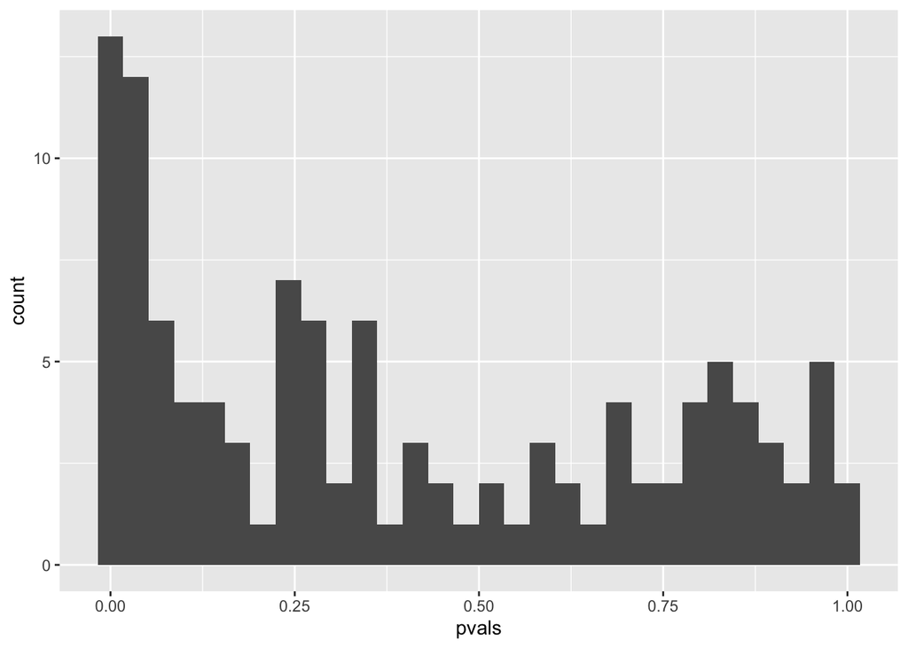

```r
wilcoxon_data<-data.frame(pvals=wilcox_pvalues,logfc=log2_foldchanges_wilcox,
                          pvals_22G=wilcox_pvalues_ttgs,logfc_22G=log2_foldchanges_ttgs,
                          ups_22Gs=ups_22Gs,downs_22Gs=downs_22Gs,ups_mRNA=ups_mRNA,downs_mRNA=downs_mRNA)
rownames(wilcoxon_data)<-genes
wilcoxon_data$padj<-p.adjust(wilcoxon_data$pvals,method = "fdr")
wilcoxon_data$log10_pvals<-(-log10(wilcoxon_data$pvals))
wilcoxon_data$padj_22G<-p.adjust(wilcoxon_data$pvals_22G,method = "fdr")
wilcoxon_data$log10_pvals_22G<-(-log10(wilcoxon_data$pvals_22G))

#mRNA data
ggplot(wilcoxon_data)+geom_histogram(aes(x=pvals))
```

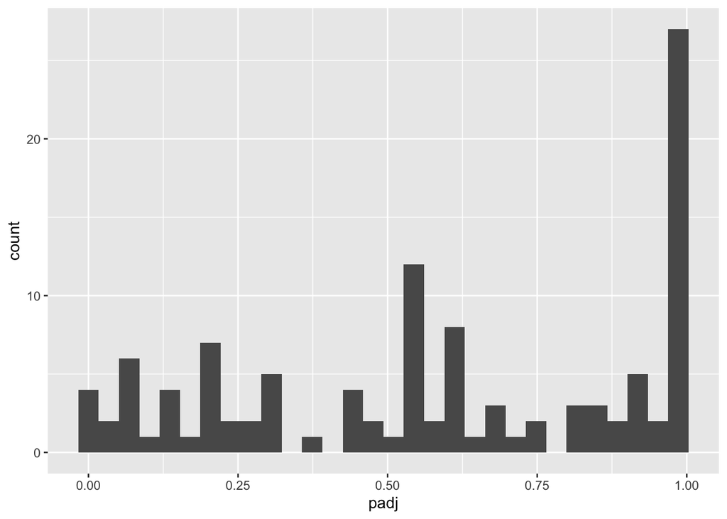

```r
ggplot(wilcoxon_data)+geom_histogram(aes(x=padj))
```

```r
length(which(wilcoxon_data$pvals<0.1))
```

```
## [1] 34
```

```r
length(which(wilcoxon_data$pvals<0.1))/nrow(wilcoxon_data)
```

```
## [1] 0.300885
```

```r
length(which(wilcoxon_data$pvals<0.1 & wilcoxon_data$logfc>0))
```

```
## [1] 15
```

```r
length(which(wilcoxon_data$pvals<0.1 & wilcoxon_data$logfc>0))/nrow(wilcoxon_data)
```

```
## [1] 0.1327434
```

```r
length(which(wilcoxon_data$pvals<0.1 & wilcoxon_data$logfc<0))
```

```
## [1] 19
```

```r
length(which(wilcoxon_data$pvals<0.1 & wilcoxon_data$logfc<0))/nrow(wilcoxon_data)
```

```
## [1] 0.1681416
```

```r
length(which(wilcoxon_data$padj<0.2))
```

```
## [1] 18
```

```r
length(which(wilcoxon_data$padj<0.2))/nrow(wilcoxon_data)
```

```
## [1] 0.159292
```

```r
length(which(wilcoxon_data$padj<0.2 & wilcoxon_data$logfc>0))
```

```
## [1] 7
```

```r
length(which(wilcoxon_data$padj<0.2 & wilcoxon_data$logfc>0))/nrow(wilcoxon_data)
```

```
## [1] 0.0619469
```

```r
length(which(wilcoxon_data$padj<0.2 & wilcoxon_data$logfc<0))
```

```
## [1] 11
```

```r
length(which(wilcoxon_data$padj<0.2 & wilcoxon_data$logfc<0))/nrow(wilcoxon_data)
```

```
## [1] 0.09734513
```

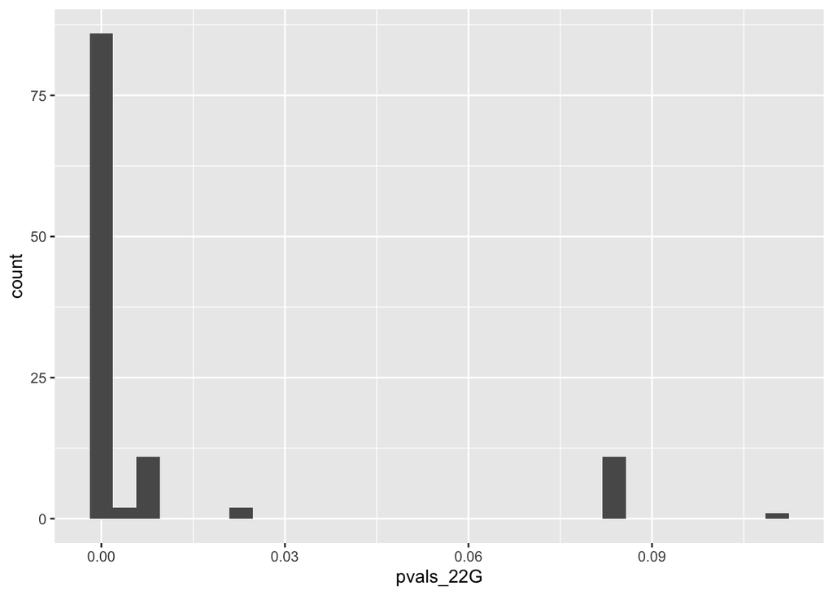

```r
#22G data
ggplot(wilcoxon_data)+geom_histogram(aes(x=pvals_22G))
```

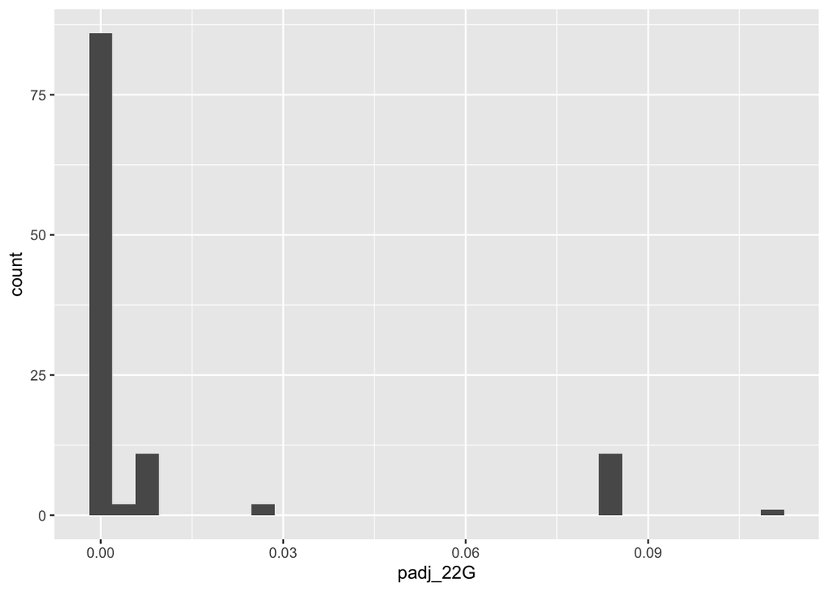

```r
ggplot(wilcoxon_data)+geom_histogram(aes(x=padj_22G))
```

```r
length(which(wilcoxon_data$pvals_22G<0.1))
```

```
## [1] 112
```

```r
length(which(wilcoxon_data$pvals_22G<0.1))/nrow(wilcoxon_data)
```

```
## [1] 0.9911504
```

```r
length(which(wilcoxon_data$pvals_22G<0.1 & wilcoxon_data$logfc_22G>0))
```

```
## [1] 112
```

```r
length(which(wilcoxon_data$pvals_22G<0.1 & wilcoxon_data$logfc_22G>0))/nrow(wilcoxon_data)
```

```
## [1] 0.9911504
```

```r
length(which(wilcoxon_data$pvals_22G<0.1 & wilcoxon_data$logfc_22G<0))
```

```
## [1] 0
```

```r
length(which(wilcoxon_data$pvals_22G<0.1 & wilcoxon_data$logfc_22G<0))/nrow(wilcoxon_data)
```

```
## [1] 0
```

```r
length(which(wilcoxon_data$padj_22G<0.2))
```

```
## [1] 113
```

```r
length(which(wilcoxon_data$padj_22G<0.2))/nrow(wilcoxon_data)
```

```
## [1] 1
```

```r
length(which(wilcoxon_data$padj_22G<0.2 & wilcoxon_data$logfc_22G>0))
```

```
## [1] 113
```

```r
length(which(wilcoxon_data$padj_22G<0.2 & wilcoxon_data$logfc_22G>0))/nrow(wilcoxon_data)
```

```
## [1] 1
```

```r
length(which(wilcoxon_data$padj_22G<0.2 & wilcoxon_data$logfc_22G<0))
```

```
## [1] 0
```

```r
length(which(wilcoxon_data$padj_22G<0.2 & wilcoxon_data$logfc_22G<0))/nrow(wilcoxon_data)
```

```
## [1] 0
```

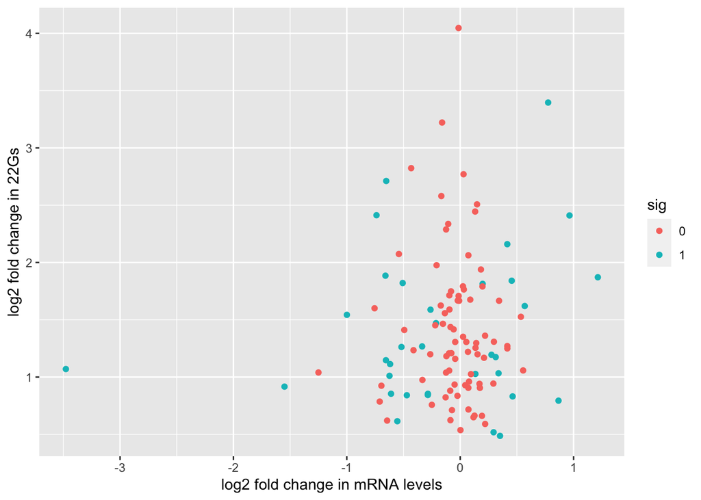

```r
wilcoxon_data$sig<-rep(0,nrow(wilcoxon_data))
wilcoxon_data[wilcoxon_data$pvals<=0.1,"sig"]<-1; wilcoxon_data$sig<-as.factor(wilcoxon_data$sig)

ggplot(wilcoxon_data)+geom_point(aes(x=logfc,y=logfc_22G,color=sig))+xlab("log2 fold change in mRNA levels")+ylab("log2 fold change in 22Gs")
```

## Wilcoxon rank sum test on the RNA-seq counts of samples with high and low small RNAs (all samples, including the consecutive generation experiment and the 25th and 100th generation experiment)

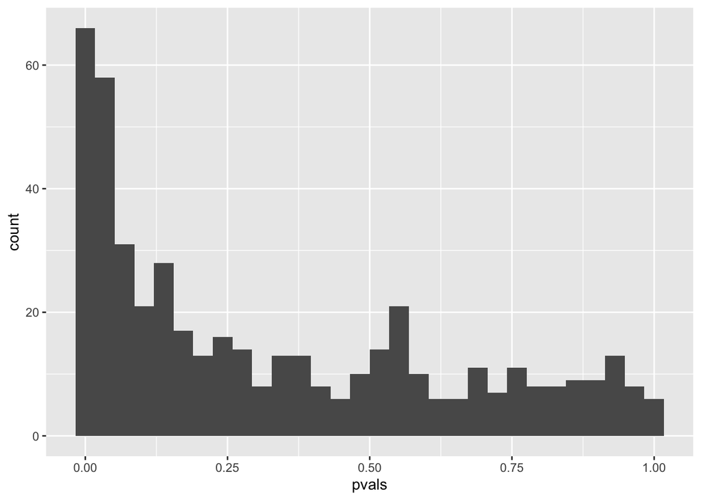

```r
kmeans_clusters_byrow_all_genbygen<-read.table("kmeans-segmentation_p1e-4_epimutable_genes")
kmeans_clusters_byrow_all_gens25_100<-read.table("../03_Figure1/k-means_segmentation_epimutable_genes.txt")
epi_genes_all<-union(rownames(kmeans_clusters_byrow_all_genbygen),rownames(kmeans_clusters_byrow_all_gens25_100))

kmeans_clusters_both_experiments<-data.frame(rbind(kmeans_clusters_byrow_all_genbygen,kmeans_clusters_byrow_all_gens25_100))
kmeans_clusters_both_experiments<-kmeans_clusters_both_experiments[which(rownames(kmeans_clusters_both_experiments) %in% epi_genes_all),]


wilcox_pvalues<-vector()
log2_foldchanges_wilcox<-vector()
ups_mRNA<-vector()
downs_mRNA<-vector()

wilcox_pvalues_ttgs<-vector()
log2_foldchanges_ttgs<-vector()
ups_22Gs<-vector()
downs_22Gs<-vector()
genes<-vector()

for (gene in rownames(kmeans_clusters_both_experiments)){
  if (gene %in% rownames(RNAseq_DEseqnorm)){
  rnaseq<-as.numeric(RNAseq_DEseqnorm[gene,])
  ones<-rnaseq[which(kmeans_clusters_both_experiments[gene,]==1)]
  twos<-rnaseq[which(kmeans_clusters_both_experiments[gene,]==2)]
  test<-suppressWarnings(wilcox.test(as.numeric(ones),as.numeric(twos)))
  wilcox_pvalues<-c(wilcox_pvalues,test$p.value)
  genes<-c(genes,gene)
  logfc<-log2(mean(as.numeric(twos))+1)-log2(mean(as.numeric(ones))+1)
  log2_foldchanges_wilcox<-c(log2_foldchanges_wilcox,logfc)
  ups_mRNA<-c(ups_mRNA,mean(as.numeric(twos)))
  downs_mRNA<-c(downs_mRNA,mean(as.numeric(ones)))


  ttg<-ttg_DEseqnorm[gene,]
  ttg_ones<-ttg[which(kmeans_clusters_both_experiments[gene,]==1)]
  ttg_twos<-ttg[which(kmeans_clusters_both_experiments[gene,]==2)]
  test<-suppressWarnings(wilcox.test(as.numeric(ttg_ones),as.numeric(ttg_twos)))
  wilcox_pvalues_ttgs<-c(wilcox_pvalues_ttgs,test$p.value)
  logfc<-log2(mean(as.numeric(ttg_twos))+1)-log2(mean(as.numeric(ttg_ones))+1)
  log2_foldchanges_ttgs<-c(log2_foldchanges_ttgs,logfc)
  ups_22Gs<-c(ups_22Gs,mean(as.numeric(ttg_twos)))
  downs_22Gs<-c(downs_22Gs,mean(as.numeric(ttg_ones)))

}}

wilcoxon_data<-data.frame(pvals=wilcox_pvalues,logfc=log2_foldchanges_wilcox,
                          pvals_22G=wilcox_pvalues_ttgs,logfc_22G=log2_foldchanges_ttgs,
                          ups_22Gs=ups_22Gs,downs_22Gs=downs_22Gs,ups_mRNA=ups_mRNA,downs_mRNA=downs_mRNA)
rownames(wilcoxon_data)<-genes
wilcoxon_data$padj<-p.adjust(wilcoxon_data$pvals,method = "fdr")
wilcoxon_data$log10_pvals<-(-log10(wilcoxon_data$pvals))
wilcoxon_data$padj_22G<-p.adjust(wilcoxon_data$pvals_22G,method = "fdr")
wilcoxon_data$log10_pvals_22G<-(-log10(wilcoxon_data$pvals_22G))




#mRNA data
ggplot(wilcoxon_data)+geom_histogram(aes(x=pvals))
```

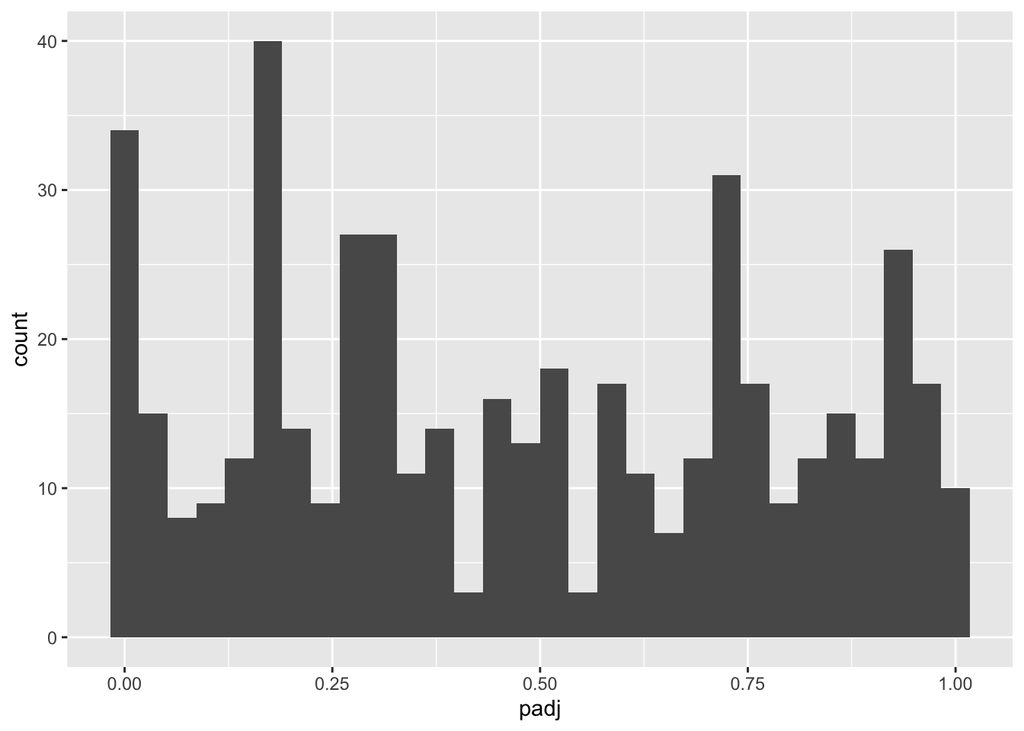

```r
ggplot(wilcoxon_data)+geom_histogram(aes(x=padj))
```

```r
length(which(wilcoxon_data$pvals<0.1))
```

```
## [1] 167
```

```r
length(which(wilcoxon_data$pvals<0.1))/nrow(wilcoxon_data)
```

```
## [1] 0.3560768
```

```r
length(which(wilcoxon_data$pvals<0.1 & wilcoxon_data$logfc>0))
```

```
## [1] 91
```

```r
length(which(wilcoxon_data$pvals<0.1 & wilcoxon_data$logfc>0))/nrow(wilcoxon_data)
```

```
## [1] 0.1940299
```

```r
length(which(wilcoxon_data$pvals<0.1 & wilcoxon_data$logfc<0))
```

```
## [1] 76
```

```r
length(which(wilcoxon_data$pvals<0.1 & wilcoxon_data$logfc<0))/nrow(wilcoxon_data)
```

```
## [1] 0.1620469
```

```r
length(which(wilcoxon_data$padj<0.2))
```

```
## [1] 126
```

```r
length(which(wilcoxon_data$padj<0.2))/nrow(wilcoxon_data)
```

```
## [1] 0.2686567
```

```r
length(which(wilcoxon_data$padj<0.2 & wilcoxon_data$logfc>0))
```

```
## [1] 66
```

```r
length(which(wilcoxon_data$padj<0.2 & wilcoxon_data$logfc>0))/nrow(wilcoxon_data)
```

```
## [1] 0.1407249
```

```r
length(which(wilcoxon_data$padj<0.2 & wilcoxon_data$logfc<0))
```

```
## [1] 60
```

```r
length(which(wilcoxon_data$padj<0.2 & wilcoxon_data$logfc<0))/nrow(wilcoxon_data)
```

```
## [1] 0.1279318
```

```r
length(which(wilcoxon_data$padj<0.1))
```

```
## [1] 59
```

```r
length(which(wilcoxon_data$padj<0.1))/nrow(wilcoxon_data)
```

```
## [1] 0.1257996
```

```r
length(which(wilcoxon_data$padj<0.1 & wilcoxon_data$logfc>0))
```

```
## [1] 29
```

```r
length(which(wilcoxon_data$padj<0.1 & wilcoxon_data$logfc>0))/nrow(wilcoxon_data)
```

```
## [1] 0.06183369
```

```r
length(which(wilcoxon_data$padj<0.1 & wilcoxon_data$logfc<0))
```

```
## [1] 30
```

```r
length(which(wilcoxon_data$padj<0.1 & wilcoxon_data$logfc<0))/nrow(wilcoxon_data)
```

```
## [1] 0.06396588
```

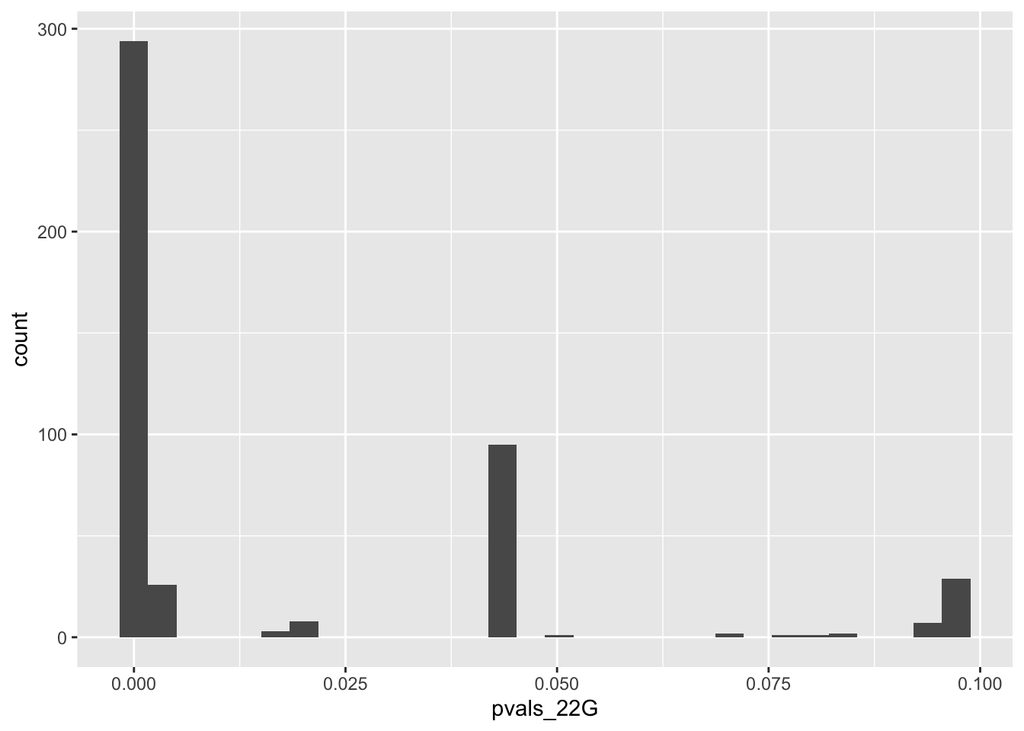

```r
#22G data
ggplot(wilcoxon_data)+geom_histogram(aes(x=pvals_22G))
```

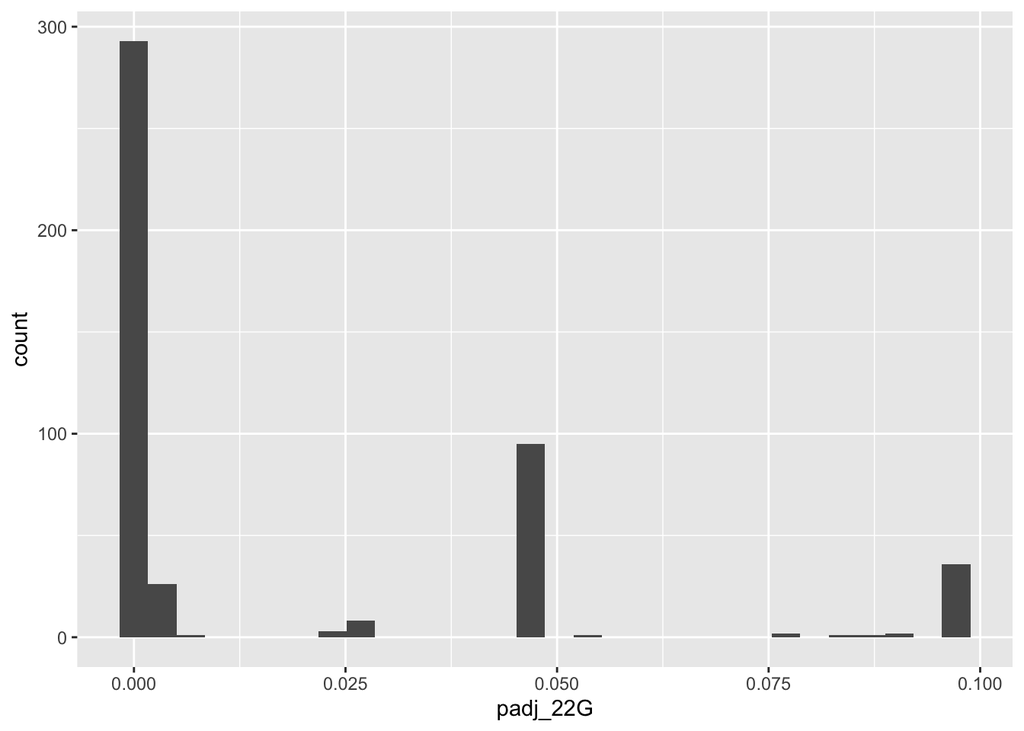

```r
ggplot(wilcoxon_data)+geom_histogram(aes(x=padj_22G))
```

```r
length(which(wilcoxon_data$pvals_22G<0.1))
```

```
## [1] 469
```

```r
length(which(wilcoxon_data$pvals_22G<0.1))/nrow(wilcoxon_data)
```

```
## [1] 1
```

```r
length(which(wilcoxon_data$pvals_22G<0.1 & wilcoxon_data$logfc_22G>0))
```

```
## [1] 469
```

```r
length(which(wilcoxon_data$pvals_22G<0.1 & wilcoxon_data$logfc_22G>0))/nrow(wilcoxon_data)
```

```
## [1] 1
```

```r
length(which(wilcoxon_data$pvals_22G<0.1 & wilcoxon_data$logfc_22G<0))
```

```
## [1] 0
```

```r
length(which(wilcoxon_data$pvals_22G<0.1 & wilcoxon_data$logfc_22G<0))/nrow(wilcoxon_data)
```

```
## [1] 0
```

```r
length(which(wilcoxon_data$padj_22G<0.2))
```

```
## [1] 469
```

```r
length(which(wilcoxon_data$padj_22G<0.2))/nrow(wilcoxon_data)
```

```
## [1] 1
```

```r
length(which(wilcoxon_data$padj_22G<0.2 & wilcoxon_data$logfc_22G>0))
```

```
## [1] 469
```

```r
length(which(wilcoxon_data$padj_22G<0.2 & wilcoxon_data$logfc_22G>0))/nrow(wilcoxon_data)
```

```
## [1] 1
```

```r
length(which(wilcoxon_data$padj_22G<0.2 & wilcoxon_data$logfc_22G<0))
```

```
## [1] 0
```

```r
length(which(wilcoxon_data$padj_22G<0.2 & wilcoxon_data$logfc_22G<0))/nrow(wilcoxon_data)
```

```
## [1] 0
```

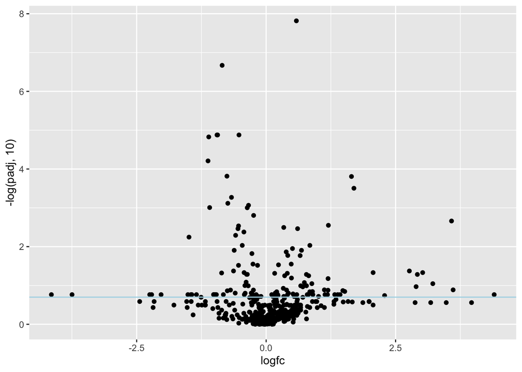

```r
wilcoxon_data$sig<-rep(0,nrow(wilcoxon_data))
wilcoxon_data[wilcoxon_data$pvals<=0.1,"sig"]<-1; wilcoxon_data$sig<-as.factor(wilcoxon_data$sig)


ggplot(wilcoxon_data)+geom_point(aes(x=logfc,y=-log(padj,10)))+geom_hline(yintercept=-log10(0.2),col="lightblue")
```

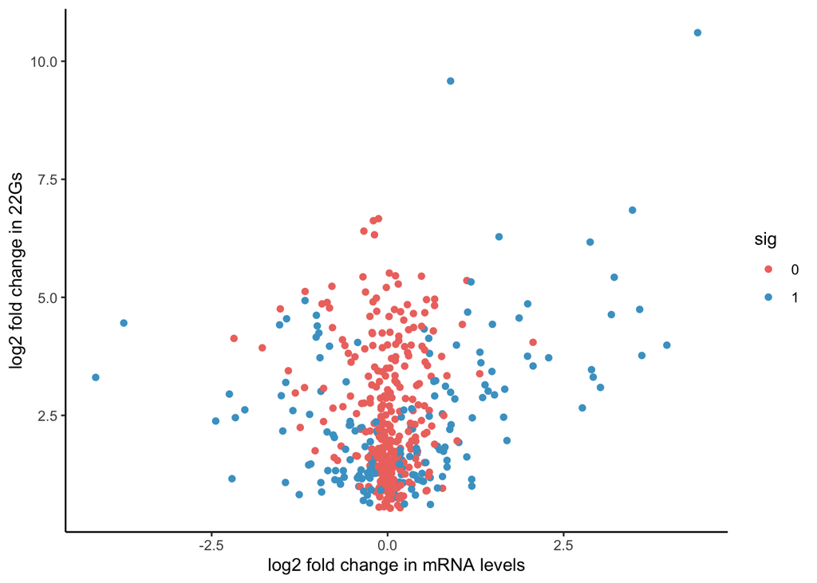

```r
ggplot(wilcoxon_data)+geom_point(aes(x=logfc,y=logfc_22G,color=sig))+xlab("log2 fold change in mRNA levels")+ylab("log2 fold change in 22Gs")+theme_classic()+scale_color_manual(values = c("#EE756E","#47A2CC"))
```

```r
ggsave("log2FC_mRNA_vs_22Gs_epimutations_p1e-4.pdf",dpi="retina")
```

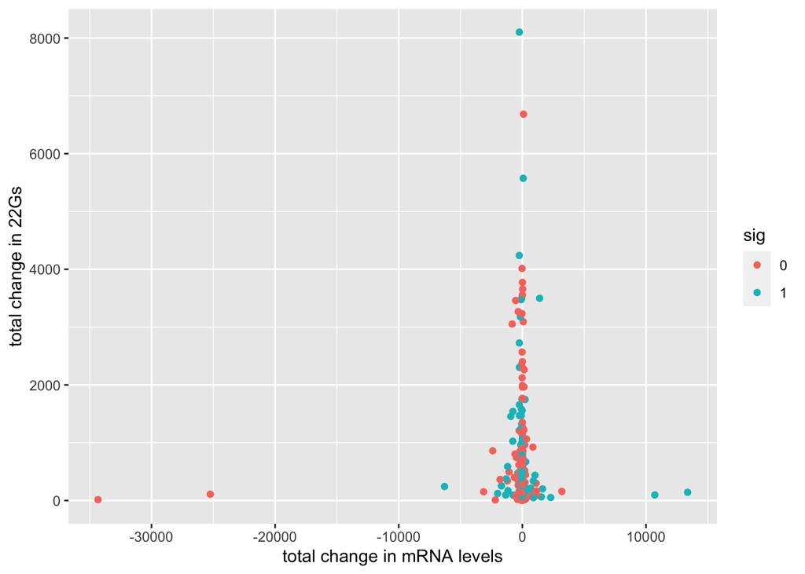

```r
write.table(wilcoxon_data,file="RNAseq_tests_wilcoxon.txt")


wilcoxon_data$totalchange_22Gs<-wilcoxon_data$ups_22Gs-wilcoxon_data$downs_22Gs
wilcoxon_data$totalchange_mRNA<-wilcoxon_data$ups_mRNA-wilcoxon_data$downs_mRNA
wilcoxon_data$totalchange_22Gs_log<-log2(abs(wilcoxon_data$totalchange_22Gs))
wilcoxon_data$totalchange_mRNA_log<-log2(abs(wilcoxon_data$totalchange_mRNA))


ggplot(wilcoxon_data)+geom_point(aes(x=totalchange_mRNA,y=totalchange_22Gs,color=sig))+xlab("total change in mRNA levels")+ylab("total change in 22Gs")
```

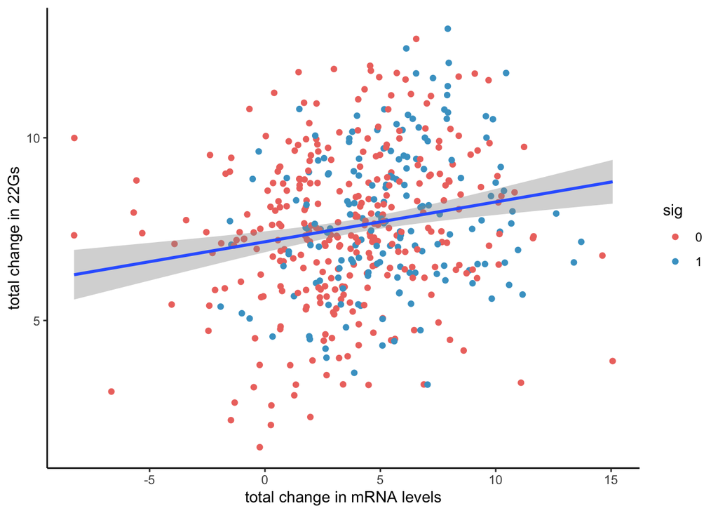

```r
ggplot(wilcoxon_data)+geom_point(aes(x=totalchange_mRNA_log,y=totalchange_22Gs_log,color=sig))+xlab("total change in mRNA levels")+ylab("total change in 22Gs")+scale_color_manual(values = c("#EE756E","#47A2CC"))+
  theme_classic()+geom_smooth(aes(x=totalchange_mRNA_log,y=totalchange_22Gs_log),method='lm')
```

```r
ggsave("logscale_absolutechanges_in_mRNAs_vs_22Gs.pdf",device = "pdf")
cor.test(wilcoxon_data$totalchange_22Gs_log,wilcoxon_data$totalchange_mRNA_log)
```

```
##
##  Pearson's product-moment correlation
##
## data:  wilcoxon_data$totalchange_22Gs_log and wilcoxon_data$totalchange_mRNA_log
## t = 4.0819, df = 467, p-value = 5.254e-05
## alternative hypothesis: true correlation is not equal to 0
## 95 percent confidence interval:
##  0.09668583 0.27158659
## sample estimates:
##       cor
## 0.1856059
```

```r
cor(wilcoxon_data$totalchange_22Gs_log,wilcoxon_data$totalchange_mRNA_log)
```

```
## [1] 0.1856059
```

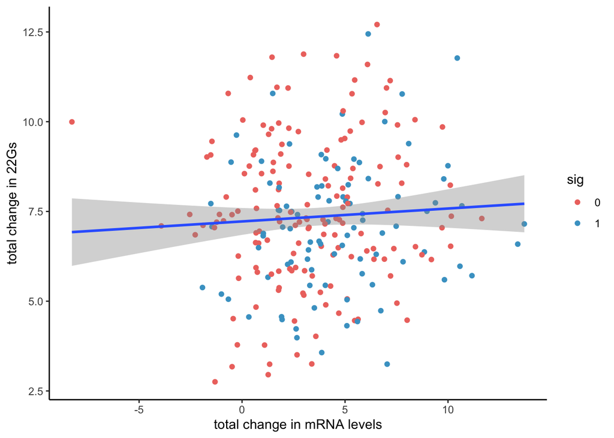

```r
wilcoxon_data_22G_pos<-wilcoxon_data[which(wilcoxon_data$logfc>0),]
ggplot(wilcoxon_data_22G_pos)+geom_point(aes(x=totalchange_mRNA_log,y=totalchange_22Gs_log,color=sig))+xlab("total change in mRNA levels")+ylab("total change in 22Gs")+scale_color_manual(values = c("#EE756E","#47A2CC"))+
  theme_classic()+geom_smooth(aes(x=totalchange_mRNA_log,y=totalchange_22Gs_log),method='lm')
```

```r
ggsave("logscale_absolutechanges_in_mRNAs_vs_22Gs_poscor.pdf",device = "pdf")
cor.test(wilcoxon_data_22G_pos$totalchange_22Gs_log,wilcoxon_data_22G_pos$totalchange_mRNA_log)
```

```
##
##  Pearson's product-moment correlation
##
## data:  wilcoxon_data_22G_pos$totalchange_22Gs_log and wilcoxon_data_22G_pos$totalchange_mRNA_log
## t = 0.936, df = 246, p-value = 0.3502
## alternative hypothesis: true correlation is not equal to 0
## 95 percent confidence interval:
##  -0.06548206  0.18278178
## sample estimates:
##        cor
## 0.05957099
```

```r
cor(wilcoxon_data_22G_pos$totalchange_22Gs_log,wilcoxon_data_22G_pos$totalchange_mRNA_log)
```

```
## [1] 0.05957099
```

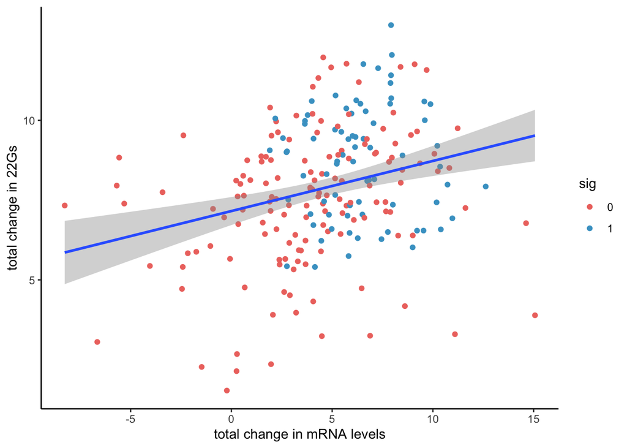

```r
wilcoxon_data_22G_neg<-wilcoxon_data[which(wilcoxon_data$logfc<0),]
ggplot(wilcoxon_data_22G_neg)+geom_point(aes(x=totalchange_mRNA_log,y=totalchange_22Gs_log,color=sig))+xlab("total change in mRNA levels")+ylab("total change in 22Gs")+scale_color_manual(values = c("#EE756E","#47A2CC"))+
  theme_classic()+geom_smooth(aes(x=totalchange_mRNA_log,y=totalchange_22Gs_log),method='lm')
```

```r
ggsave("logscale_absolutechanges_in_mRNAs_vs_22Gs_negcor.pdf",device = "pdf")
cor.test(wilcoxon_data_22G_neg$totalchange_22Gs_log,wilcoxon_data_22G_neg$totalchange_mRNA_log)
```

```
##
##  Pearson's product-moment correlation
##
## data:  wilcoxon_data_22G_neg$totalchange_22Gs_log and wilcoxon_data_22G_neg$totalchange_mRNA_log
## t = 4.2124, df = 219, p-value = 3.691e-05
## alternative hypothesis: true correlation is not equal to 0
## 95 percent confidence interval:
##  0.1471196 0.3915979
## sample estimates:
##       cor
## 0.2737753
```

```r
cor(wilcoxon_data_22G_neg$totalchange_22Gs_log,wilcoxon_data_22G_neg$totalchange_mRNA_log)
```

```
## [1] 0.2737753
```

## Chromatin locations of genes on the plot

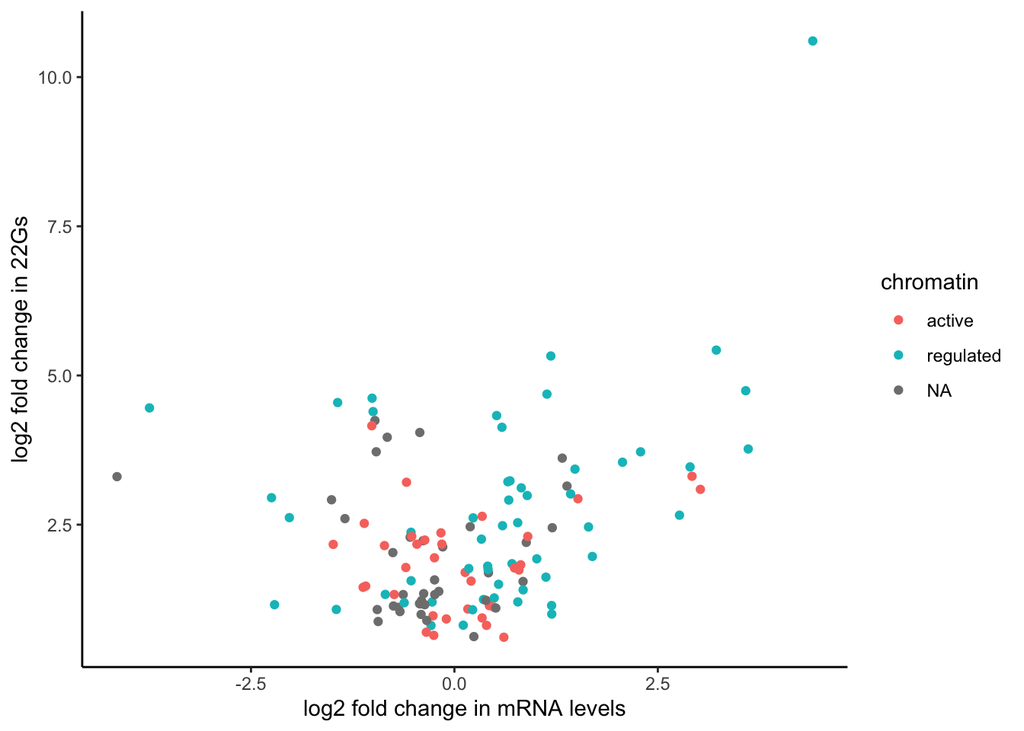

```r
active<-read.table("../07_Gene_Sets/active_cosmidID")
border<-read.table("../07_Gene_Sets/border_cosmidID")
regulated<-read.table("../07_Gene_Sets/regulated_cosmidID")
X<-read.table("../07_Gene_Sets/X_cosmidID")

wilcoxon_data_chrom_info<-wilcoxon_data[which(wilcoxon_data$padj<0.2),]
wilcoxon_data_chrom_info$chromatin<-rep(NA,nrow(wilcoxon_data_chrom_info))
wilcoxon_data_chrom_info[which(rownames(wilcoxon_data_chrom_info) %in% active$V1),"chromatin"]<-"active"
wilcoxon_data_chrom_info[which(rownames(wilcoxon_data_chrom_info) %in% regulated$V1),"chromatin"]<-"regulated"

ggplot(wilcoxon_data_chrom_info)+geom_point(aes(x=logfc,y=logfc_22G,color=chromatin))+xlab("log2 fold change in mRNA levels")+ylab("log2 fold change in 22Gs")+theme_classic()
```

```r
ggsave("RNAseq_by_chromatin_domain_act_reg.pdf",dpi="retina")
```

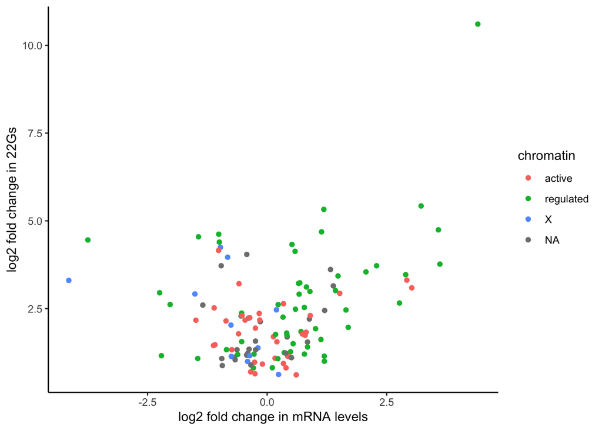

```r
wilcoxon_data_chrom_info[which(rownames(wilcoxon_data_chrom_info) %in% X$V1),"chromatin"]<-"X"
ggplot(wilcoxon_data_chrom_info)+geom_point(aes(x=logfc,y=logfc_22G,color=chromatin))+xlab("log2 fold change in mRNA levels")+ylab("log2 fold change in 22Gs")+theme_classic()
```

```r
ggsave("RNAseq_by_chromatin_domain_act_reg_X.pdf",dpi="retina")
```

## Testing whether the set of epimutable genes is enriched in changes at the mRNA level

We repeat the same analysis for random sets of genes of the same size as the epimutable set. Background genes are first filtered to have at least the minimum 22G abundance required to be called as epimutable. These are then segmented, and differences in mRNA levels between high and low small RNA groups are assessed in the same way as above (Wilcoxon rank sum test).

```r
#select genes with >10 22G normalised counts
ttg_DEseqnorm_genomewide_segmentation<-ttg_DEseqnorm[which(rownames(ttg_DEseqnorm) %in% rownames(summary_stats_all[which(summary_stats_all$mean>10),])),]

#segment
library(nnet)

kmeans_row<-function(vector){
  kmc<-kmeans(x = as.numeric(vector),centers=2)
  high<-kmc$cluster[which.is.max(vector)]
  if (high==2){return(kmc$cluster)
  }else{return(abs(kmc$cluster-3))}
}

kmeans_clusters_GW<-matrix(0,nrow=nrow(ttg_DEseqnorm_genomewide_segmentation),ncol = 47)
rownames(kmeans_clusters_GW)<-rownames(ttg_DEseqnorm_genomewide_segmentation)
for (gene in rownames(ttg_DEseqnorm_genomewide_segmentation)){
      kmeans_clusters_GW[gene,]<-kmeans_row(ttg_DEseqnorm_genomewide_segmentation[gene,])
}
colnames(kmeans_clusters_GW)<-colnames(ttg_DEseqnorm_genomewide_segmentation)


nrow(kmeans_clusters_GW)
```

```
## [1] 6986
```

```r
#I am sampling a random gene from the mRNA counts table
#and its corresponding segmentation from the kmeans table
#and using them for the analysis - what fraction of changes are significant? How does this compare to the real dataset?
RNAseq_DEseqnorm_controls<-RNAseq_DEseqnorm[which(rownames(RNAseq_DEseqnorm) %in% rownames(kmeans_clusters_GW)),]
nrow(RNAseq_DEseqnorm_controls)
```

```
## [1] 6427
```

```r
total_p0.1<-rep(0,500)
total_samedir_p0.1<-rep(0,500)
total_oppdir_p0.1<-rep(0,500)

total_fdr0.2<-rep(0,500)
total_samedir_fdr0.2<-rep(0,500)
total_oppdir_fdr0.2<-rep(0,500)

total_fdr0.1<-rep(0,500)
total_samedir_fdr0.1<-rep(0,500)
total_oppdir_fdr0.1<-rep(0,500)

for (reps in seq(500)){

  if (reps %in% c(10,50,100,200,300,400,500)){
  print(reps)}

  wilcox_pvalues<-rep(0,469)
  log2_foldchanges_wilcox<-rep(0,469)


for (i in seq(469)){
  rand_gene<-rownames(RNAseq_DEseqnorm_controls)[round(runif(1,min=0.5,max=nrow(RNAseq_DEseqnorm_controls)+0.49999))]

  rnaseq<-as.numeric(RNAseq_DEseqnorm_controls[rand_gene,])
  ones<-rnaseq[which(kmeans_clusters_GW[rand_gene,]==1)]
  twos<-rnaseq[which(kmeans_clusters_GW[rand_gene,]==2)]
  test<-suppressWarnings(wilcox.test(as.numeric(ones),as.numeric(twos)))
  wilcox_pvalues[i]<-test$p.value
  logfc<-log2(mean(as.numeric(twos))+1)-log2(mean(as.numeric(ones))+1)
  log2_foldchanges_wilcox[i]<-logfc

}


wilcoxon_data_random<-data.frame(pvals=wilcox_pvalues,logfc=log2_foldchanges_wilcox)
wilcoxon_data_random$padj<-p.adjust(wilcoxon_data_random$pvals,method = "fdr")
wilcoxon_data_random$log10_pvals<-(-log10(wilcoxon_data_random$pvals))

#mRNA data

total_p0.1[reps]<-length(which(wilcoxon_data_random$pvals<0.1))
total_samedir_p0.1[reps]<-length(which(wilcoxon_data_random$pvals<0.1 & wilcoxon_data_random$logfc>0))
total_oppdir_p0.1[reps]<-length(which(wilcoxon_data_random$pvals<0.1 & wilcoxon_data_random$logfc<0))

total_fdr0.2[reps]<-length(which(wilcoxon_data_random$padj<0.2))
total_samedir_fdr0.2[reps]<-length(which(wilcoxon_data_random$padj<0.2 & wilcoxon_data_random$logfc>0))
total_oppdir_fdr0.2[reps]<-length(which(wilcoxon_data_random$padj<0.2 & wilcoxon_data_random$logfc<0))

total_fdr0.1[reps]<-length(which(wilcoxon_data_random$padj<0.1))
total_samedir_fdr0.1[reps]<-length(which(wilcoxon_data_random$padj<0.1 & wilcoxon_data_random$logfc>0))
total_oppdir_fdr0.1[reps]<-length(which(wilcoxon_data_random$padj<0.1 & wilcoxon_data_random$logfc<0))

}
```

```
## [1] 10
## [1] 50
## [1] 100
## [1] 200
## [1] 300
## [1] 400
## [1] 500
```

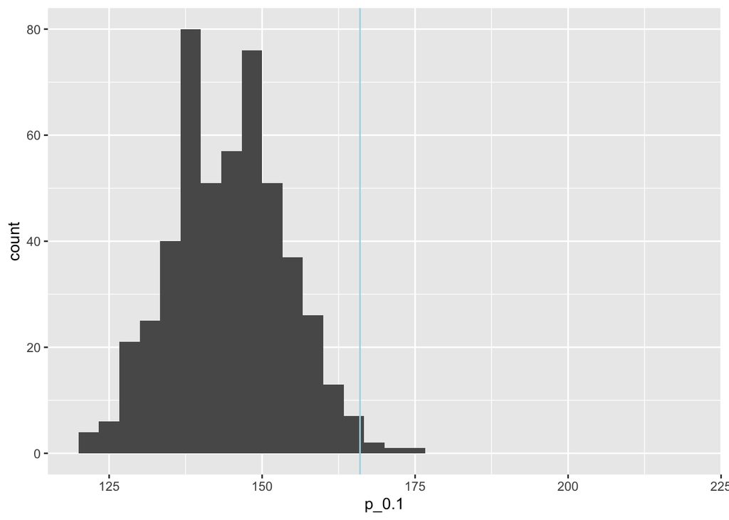

```r
summary_of_randomisation<-data.frame(p_0.1=total_p0.1,
               p_0.1_samedir=total_samedir_p0.1,
               p_0.1_oppdir=total_oppdir_p0.1,
               fdr_0.2=total_fdr0.2,
               fdr_0.2_samedir=total_samedir_fdr0.2,
               fdr_0.2_oppdir=total_oppdir_fdr0.2,
               fdr_0.1=total_fdr0.1,
               fdr_0.1_samedir=total_samedir_fdr0.1,
               fdr_0.1_oppdir=total_oppdir_fdr0.1)

ggplot(summary_of_randomisation)+geom_histogram(aes(x=p_0.1),breaks=seq(120,220,100/30))+geom_vline(xintercept = 166,color="lightblue")
```

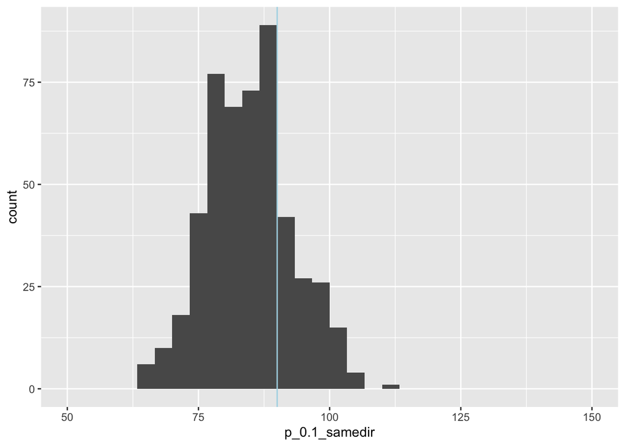

```r
ggplot(summary_of_randomisation)+geom_histogram(aes(x=p_0.1_samedir),breaks=seq(50,150,100/30))+geom_vline(xintercept = 90,color="lightblue")
```

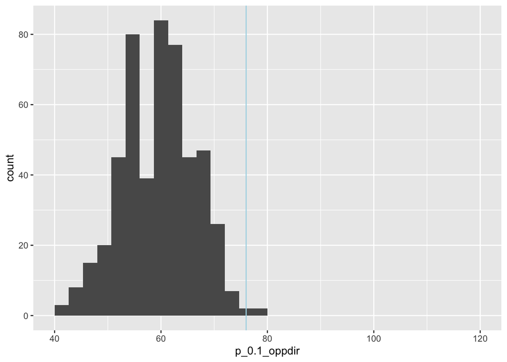

```r
ggplot(summary_of_randomisation)+geom_histogram(aes(x=p_0.1_oppdir),breaks=seq(40,120,80/30))+geom_vline(xintercept = 76,color="lightblue")
```

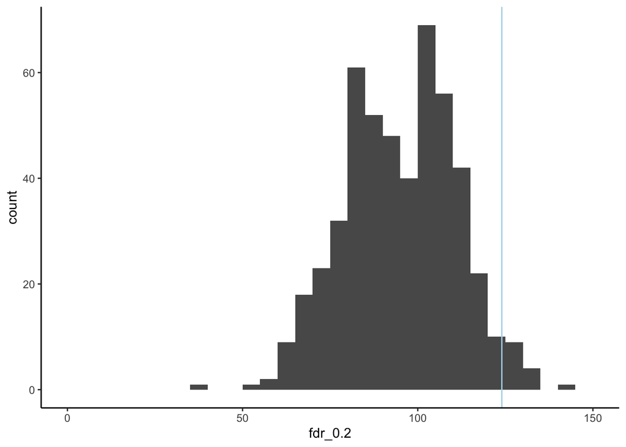

```r
ggplot(summary_of_randomisation)+geom_histogram(aes(x=fdr_0.2),breaks=seq(0,150,150/30))+geom_vline(xintercept = 124,color="lightblue")+theme_classic()
```

```r
ggsave("RNAseq_control_2_random_sets_of_genes_fdr0.2_p1e-4.pdf")
```

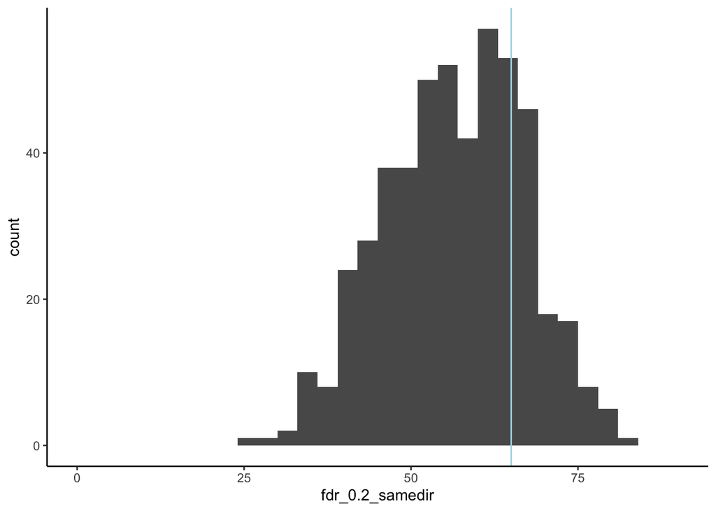

```r
ggplot(summary_of_randomisation)+geom_histogram(aes(x=fdr_0.2_samedir),breaks=seq(0,90,90/30))+geom_vline(xintercept = 65,color="lightblue")+theme_classic()
```

```r
ggsave("RNAseq_control_2_random_sets_of_genes_fdr0.2_samedir_p1e-4.pdf")
```

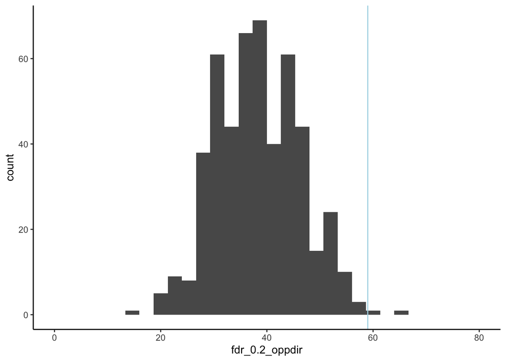

```r
ggplot(summary_of_randomisation)+geom_histogram(aes(x=fdr_0.2_oppdir),breaks=seq(0,80,80/30))+geom_vline(xintercept = 59,color="lightblue")+theme_classic()
```

```r
ggsave("RNAseq_control_2_random_sets_of_genes_fdr0.2_oppdir_p1e-4.pdf")
```

## Fold change data

This code calculates the fold changes in 22G-RNA and mRNA levels for each epimutation event and adds it to the epimutations summary table generated after the segmentation analysis - this is for downstream testing of the relationship between epimutation duration and the magnitude and direction of changes in 22G-RNA levels and mRNA levels.

```r
maplot_data_A<-ttg_MAplot_data[which((ttg_MAplot_data$line1 %in% colnames(ttg_DEseqnorm[,1:12])) &
                                        (ttg_MAplot_data$line2 %in% colnames(ttg_DEseqnorm[,1:12]))),]
maplot_data_B<-ttg_MAplot_data[which((ttg_MAplot_data$line1 %in% colnames(ttg_DEseqnorm[,13:24])) &
                                        (ttg_MAplot_data$line2 %in% colnames(ttg_DEseqnorm[,13:24]))),]

remove_char<-function(string){return(substring(string, 2))}

#select consecutive generation maplot calls
maplot_data_A$line1<-as.numeric(sapply(maplot_data_A[,"line1"],FUN=remove_char))
maplot_data_A$line2<-as.numeric(sapply(maplot_data_A[,"line2"],FUN=remove_char))
maplot_data_A<-maplot_data_A[which(abs(maplot_data_A$line1-maplot_data_A$line2)==1),]
maplot_data_B$line1<-as.numeric(sapply(maplot_data_B[,"line1"],FUN=remove_char))
maplot_data_B$line2<-as.numeric(sapply(maplot_data_B[,"line2"],FUN=remove_char))
maplot_data_B<-maplot_data_B[which(abs(maplot_data_B$line1-maplot_data_B$line2)==1),]

epimutable_genes_genbygen<-read.table("epimutable_genes_genbygen.txt")
epimutable_genes_genbygen<-epimutable_genes_genbygen$x

maplot_data_A<-maplot_data_A[which(maplot_data_A$ID %in% epimutable_genes_genbygen),]
maplot_data_B<-maplot_data_B[which(maplot_data_B$ID %in% epimutable_genes_genbygen),]


ttg_foldchanges<-vector()
mrna_foldchanges<-vector()
genes<-vector()

for (row in seq(nrow(maplot_data_A))){
  gene<-toString(maplot_data_A[row,"ID"])
  line1<-maplot_data_A[row,"line1"]; line2<-maplot_data_A[row,"line2"]
  if (line1>7){line1<-line1-1}
  if (line2>7){line2<-line2-1}
  ct1<-ttg_DEseqnorm[gene,line1]
  ct2<-ttg_DEseqnorm[gene,line2]
  ttg_foldchanges<-c(ttg_foldchanges,(log2(ct2+1)-log2(ct1+1)))

  mr1<-RNAseq_DEseqnorm[gene,line1]
  mr2<-RNAseq_DEseqnorm[gene,line2]
  mrna_foldchanges<-c(mrna_foldchanges,(log2(mr2+1)-log2(mr1+1)))

  genes<-c(genes,gene)

}

for (row in seq(nrow(maplot_data_B))){
  gene<-toString(maplot_data_B[row,"ID"])
  line1<-maplot_data_B[row,"line1"]; line2<-maplot_data_B[row,"line2"]
  if (line1>7){line1<-line1-1}
  if (line2>7){line2<-line2-1}
  ct1<-ttg_DEseqnorm[gene,line1+12]
  ct2<-ttg_DEseqnorm[gene,line2+12]
  ttg_foldchanges<-c(ttg_foldchanges,(log2(ct2+1)-log2(ct1+1)))

  mr1<-RNAseq_DEseqnorm[gene,line1+12]
  mr2<-RNAseq_DEseqnorm[gene,line2+12]
  mrna_foldchanges<-c(mrna_foldchanges,(log2(mr2+1)-log2(mr1+1)))

  genes<-c(genes,gene)

}


fold_change_consecutive_gens<-data.frame(ttg_fc=ttg_foldchanges,mrna_fc=mrna_foldchanges,ID=genes)
fold_change_consecutive_gens$fc1.5<-rep(0,nrow(fold_change_consecutive_gens))
fold_change_consecutive_gens[which(abs(fold_change_consecutive_gens$mrna_fc)>log2(1.5)),"fc1.5"]<-1
fold_change_consecutive_gens$fc1.5<-as.factor(fold_change_consecutive_gens$fc1.5)


length(which(fold_change_consecutive_gens$fc1.5==1))
```

```
## [1] 8
```

```r
length(which(fold_change_consecutive_gens$fc1.5==1))/nrow(fold_change_consecutive_gens)
```

```
## [1] 0.1702128
```

```r
length(which(fold_change_consecutive_gens$fc1.5==1 &
             fold_change_consecutive_gens$mrna_fc*fold_change_consecutive_gens$ttg_fc >0))
```

```
## [1] 5
```

```r
length(which(fold_change_consecutive_gens$fc1.5==1 &
             fold_change_consecutive_gens$mrna_fc*fold_change_consecutive_gens$ttg_fc >0))/length(which(fold_change_consecutive_gens$fc1.5==1))
```

```
## [1] 0.625
```

```r
length(which(fold_change_consecutive_gens$fc1.5==1 &
             fold_change_consecutive_gens$mrna_fc*fold_change_consecutive_gens$ttg_fc <0))
```

```
## [1] 3
```

```r
length(which(fold_change_consecutive_gens$fc1.5==1 &
             fold_change_consecutive_gens$mrna_fc*fold_change_consecutive_gens$ttg_fc <0))/length(which(fold_change_consecutive_gens$fc1.5==1))
```

```
## [1] 0.375
```

```r
nrow(fold_change_consecutive_gens)
```

```
## [1] 47
```

This code adds fold-change information to each individual epimutation that we see in the consecutive generation experiment. - 22G fold change, and levels before and after - mRNA fold change, and levels before and after - whether this gene is called significant by the wilcoxon test - whether this particular epimutation was detected in the MA plot analysis

```r
wilcoxon_data_sig<-wilcoxon_data[which(wilcoxon_data$padj<0.2),]
maplot_cons_sig<-rbind(maplot_data_A,maplot_data_B)

#collect full dataset in the duration table


epimut_duration_kmeans_A<-read.table("epimut_duration_batchremoved_kmeans_linA_JOINT_p1e-4.txt")
epimut_duration_kmeans_B<-read.table("epimut_duration_batchremoved_kmeans_linB_JOINT_p1e-4.txt")

#add wilcoxon significance
epimut_duration_kmeans_A$wilcox_sig<-rep(0,nrow(epimut_duration_kmeans_A))
epimut_duration_kmeans_A[which(epimut_duration_kmeans_A$ID %in% rownames(wilcoxon_data_sig)),"wilcox_sig"]<-1
epimut_duration_kmeans_B$wilcox_sig<-rep(0,nrow(epimut_duration_kmeans_B))
epimut_duration_kmeans_B[which(epimut_duration_kmeans_B$ID %in% rownames(wilcoxon_data_sig)),"wilcox_sig"]<-1

#add average mRNA fold change
epimut_duration_kmeans_A$overall_mRNA_fc<-rep(0,nrow(epimut_duration_kmeans_A))
for (i in seq(nrow(epimut_duration_kmeans_A))){
  gene<-as.character(epimut_duration_kmeans_A$ID[i])
  if (gene %in% rownames(wilcoxon_data)){
  logfc<-wilcoxon_data[which(rownames(wilcoxon_data)==gene),"logfc"]}
  else {logfc<-NA}
  epimut_duration_kmeans_A$overall_mRNA_fc[i]<-logfc
}

epimut_duration_kmeans_B$overall_mRNA_fc<-rep(0,nrow(epimut_duration_kmeans_B))
for (i in seq(nrow(epimut_duration_kmeans_B))){
  gene<-as.character(epimut_duration_kmeans_B$ID[i])
  if (gene %in% rownames(wilcoxon_data)){
  logfc<-wilcoxon_data[which(rownames(wilcoxon_data)==gene),"logfc"]}
  else {logfc<-NA}
  epimut_duration_kmeans_B$overall_mRNA_fc[i]<-logfc
}

#add wilcoxon direction of change
epimut_duration_kmeans_A$wilcox_dir<-rep(0,nrow(epimut_duration_kmeans_A))
epimut_duration_kmeans_A[which(epimut_duration_kmeans_A$ID %in% rownames(wilcoxon_data_sig) & epimut_duration_kmeans_A$ID %in% rownames(wilcoxon_data_sig[which(wilcoxon_data_sig$logfc>0),])),"wilcox_dir"]<-(1)
epimut_duration_kmeans_A[which(epimut_duration_kmeans_A$ID %in% rownames(wilcoxon_data_sig) & epimut_duration_kmeans_A$ID %in% rownames(wilcoxon_data_sig[which(wilcoxon_data_sig$logfc<0),])),"wilcox_dir"]<-(-1)

epimut_duration_kmeans_B$wilcox_dir<-rep(0,nrow(epimut_duration_kmeans_B))
epimut_duration_kmeans_B[which(epimut_duration_kmeans_B$ID %in% rownames(wilcoxon_data_sig) & epimut_duration_kmeans_B$ID %in% rownames(wilcoxon_data_sig[which(wilcoxon_data_sig$logfc>0),])),"wilcox_dir"]<-(1)
epimut_duration_kmeans_B[which(epimut_duration_kmeans_B$ID %in% rownames(wilcoxon_data_sig) & epimut_duration_kmeans_B$ID %in% rownames(wilcoxon_data_sig[which(wilcoxon_data_sig$logfc<0),])),"wilcox_dir"]<-(-1)


#add MAplot detection

maplot_cons_sig[1,]
```

```
##         ID     mean       fc         padj line1 line2
## 12 F31C3.9 11.27927 1.050519 3.083172e-07     1     2
```

```r
get_fc_data_linA<-function(row){
  ID<-toString(row[[1]])
  stgen<-as.numeric(row[[5]])
  if (stgen>7){stgen<-stgen-1}
  maplotsig<-0
  if (ID %in% rownames(RNAseq_DEseqnorm)){
  mRNA_fc<-log2(RNAseq_DEseqnorm[ID,stgen+1]+1)-log2(RNAseq_DEseqnorm[ID,stgen]+1)
  mRNA_before<-RNAseq_DEseqnorm[ID,stgen]
  mRNA_after<-RNAseq_DEseqnorm[ID,stgen+1]
  }
  ttg_fc<-log2(ttg_DEseqnorm[ID,stgen+1]+1)-log2(ttg_DEseqnorm[ID,stgen]+1)
  ttg_before<-ttg_DEseqnorm[ID,stgen]
  ttg_after<-ttg_DEseqnorm[ID,stgen+1]
  if (nrow(maplot_cons_sig[which(maplot_data_A$ID==ID & maplot_data_A$line1==stgen),])==1){
    maplotsig<-1
  }
  if (ID %in% rownames(RNAseq_DEseqnorm)){
  return(c(mRNA_fc,mRNA_before,mRNA_after,ttg_fc,ttg_before,ttg_after,maplotsig))}
  else{return(c(NA,NA,NA,ttg_fc,ttg_before,ttg_after,maplotsig))}
}

get_fc_data_linB<-function(row){
  ID<-toString(row[[1]])
  stgen<-as.numeric(row[[5]])
  if (stgen>7){stgen<-stgen-1}
  maplotsig<-0
  if (ID %in% rownames(RNAseq_DEseqnorm)){
  mRNA_fc<-log2(RNAseq_DEseqnorm[ID,stgen+13]+1)-log2(RNAseq_DEseqnorm[ID,stgen+12]+1)
  mRNA_before<-RNAseq_DEseqnorm[ID,stgen+12]
  mRNA_after<-RNAseq_DEseqnorm[ID,stgen+13]
  }
  ttg_fc<-log2(ttg_DEseqnorm[ID,stgen+13]+1)-log2(ttg_DEseqnorm[ID,stgen+12]+1)
  ttg_before<-ttg_DEseqnorm[ID,stgen+12]
  ttg_after<-ttg_DEseqnorm[ID,stgen+13]
  if (nrow(maplot_cons_sig[which(maplot_data_B$ID==ID & maplot_data_B$line1==stgen),])==1){
    maplotsig<-1
  }
  if (ID %in% rownames(RNAseq_DEseqnorm)){
  return(c(mRNA_fc,mRNA_before,mRNA_after,ttg_fc,ttg_before,ttg_after,maplotsig))}
  else{return(c(NA,NA,NA,ttg_fc,ttg_before,ttg_after,maplotsig))}
}

get_fc_data_linA(epimut_duration_kmeans_A[1,])
```

```
## [1]  -1.5101547 480.5391286 168.0556568   0.4134162 716.4884732 954.5768451
## [7]   0.0000000
```

```r
toString(epimut_duration_kmeans_A[1,][[1]])
```

```
## [1] "B0285.7"
```

```r
epimut_duration_kmeans_A_fcdata<-t(apply(epimut_duration_kmeans_A,MARGIN=1,FUN=get_fc_data_linA))
epimut_duration_kmeans_B_fcdata<-t(apply(epimut_duration_kmeans_B,MARGIN=1,FUN=get_fc_data_linB))

colnames(epimut_duration_kmeans_A_fcdata)<-c("mRNA_fold_change","mRNA_before","mRNA_after","22G_fold_change","22G_before","22G_after","MAplot_significant")
colnames(epimut_duration_kmeans_B_fcdata)<-c("mRNA_fold_change","mRNA_before","mRNA_after","22G_fold_change","22G_before","22G_after","MAplot_significant")

nrow(epimut_duration_kmeans_A_fcdata)
```

```
## [1] 259
```

```r
nrow(epimut_duration_kmeans_A)
```

```
## [1] 259
```

```r
epimut_duration_kmeans_A<-cbind(epimut_duration_kmeans_A,epimut_duration_kmeans_A_fcdata)
epimut_duration_kmeans_B<-cbind(epimut_duration_kmeans_B,epimut_duration_kmeans_B_fcdata)

write.table(epimut_duration_kmeans_A,"epimut_duration_batchremoved_kmeans_linA_JOINT_p1e-4_FCdata.txt",row.names = FALSE,quote=FALSE,sep="\t")
write.table(epimut_duration_kmeans_B,"epimut_duration_batchremoved_kmeans_linB_JOINT_p1e-4_FCdata.txt",row.names = FALSE,quote=FALSE,sep="\t")
```

## Same for HMM segmentation data

```r
wilcoxon_data_sig<-wilcoxon_data[which(wilcoxon_data$padj<0.2),]
maplot_cons_sig<-rbind(maplot_data_A,maplot_data_B)

#collect full dataset in the duration table


epimut_duration_HMM_A<-read.table("epimut_duration_batchremoved_HMM_linA_JOINT_p1e-4.txt",header=TRUE)
epimut_duration_HMM_B<-read.table("epimut_duration_batchremoved_HMM_linB_JOINT_p1e-4.txt",header=TRUE)

#add wilcoxon significance
epimut_duration_HMM_A$wilcox_sig<-rep(0,nrow(epimut_duration_HMM_A))
epimut_duration_HMM_A[which(epimut_duration_HMM_A$ID %in% rownames(wilcoxon_data_sig)),"wilcox_sig"]<-1
epimut_duration_HMM_B$wilcox_sig<-rep(0,nrow(epimut_duration_HMM_B))
epimut_duration_HMM_B[which(epimut_duration_HMM_B$ID %in% rownames(wilcoxon_data_sig)),"wilcox_sig"]<-1

#add wilcoxon direction of change
epimut_duration_HMM_A$wilcox_dir<-rep(0,nrow(epimut_duration_HMM_A))
epimut_duration_HMM_A[which(epimut_duration_HMM_A$ID %in% rownames(wilcoxon_data_sig) & epimut_duration_HMM_A$ID %in% rownames(wilcoxon_data_sig[which(wilcoxon_data_sig$logfc>0),])),"wilcox_dir"]<-(1)
epimut_duration_HMM_A[which(epimut_duration_HMM_A$ID %in% rownames(wilcoxon_data_sig) & epimut_duration_HMM_A$ID %in% rownames(wilcoxon_data_sig[which(wilcoxon_data_sig$logfc<0),])),"wilcox_dir"]<-(-1)

epimut_duration_HMM_B$wilcox_dir<-rep(0,nrow(epimut_duration_HMM_B))
epimut_duration_HMM_B[which(epimut_duration_HMM_B$ID %in% rownames(wilcoxon_data_sig) & epimut_duration_HMM_B$ID %in% rownames(wilcoxon_data_sig[which(wilcoxon_data_sig$logfc>0),])),"wilcox_dir"]<-(1)
epimut_duration_HMM_B[which(epimut_duration_HMM_B$ID %in% rownames(wilcoxon_data_sig) & epimut_duration_HMM_B$ID %in% rownames(wilcoxon_data_sig[which(wilcoxon_data_sig$logfc<0),])),"wilcox_dir"]<-(-1)


#add MAplot detection

maplot_cons_sig[1,]
```

```
##         ID     mean       fc         padj line1 line2
## 12 F31C3.9 11.27927 1.050519 3.083172e-07     1     2
```

```r
get_fc_data_linA<-function(row){
  ID<-toString(row[[1]])
  stgen<-as.numeric(row[[5]])
  if (stgen>7){stgen<-stgen-1}
  maplotsig<-0
  if (ID %in% rownames(RNAseq_DEseqnorm)){
  mRNA_fc<-log2(RNAseq_DEseqnorm[ID,stgen+1]+1)-log2(RNAseq_DEseqnorm[ID,stgen]+1)
  mRNA_before<-RNAseq_DEseqnorm[ID,stgen]
  mRNA_after<-RNAseq_DEseqnorm[ID,stgen+1]
  }
  ttg_fc<-log2(ttg_DEseqnorm[ID,stgen+1]+1)-log2(ttg_DEseqnorm[ID,stgen]+1)
  ttg_before<-ttg_DEseqnorm[ID,stgen]
  ttg_after<-ttg_DEseqnorm[ID,stgen+1]
  if (nrow(maplot_cons_sig[which(maplot_data_A$ID==ID & maplot_data_A$line1==stgen),])==1){
    maplotsig<-1
  }
  if (ID %in% rownames(RNAseq_DEseqnorm)){
  return(c(mRNA_fc,mRNA_before,mRNA_after,ttg_fc,ttg_before,ttg_after,maplotsig))}
  else{return(c(NA,NA,NA,ttg_fc,ttg_before,ttg_after,maplotsig))}
}

get_fc_data_linB<-function(row){
  ID<-toString(row[[1]])
  stgen<-as.numeric(row[[5]])
  if (stgen>7){stgen<-stgen-1}
  maplotsig<-0
  if (ID %in% rownames(RNAseq_DEseqnorm)){
  mRNA_fc<-log2(RNAseq_DEseqnorm[ID,stgen+13]+1)-log2(RNAseq_DEseqnorm[ID,stgen+12]+1)
  mRNA_before<-RNAseq_DEseqnorm[ID,stgen+12]
  mRNA_after<-RNAseq_DEseqnorm[ID,stgen+13]
  }
  ttg_fc<-log2(ttg_DEseqnorm[ID,stgen+13]+1)-log2(ttg_DEseqnorm[ID,stgen+12]+1)
  ttg_before<-ttg_DEseqnorm[ID,stgen+12]
  ttg_after<-ttg_DEseqnorm[ID,stgen+13]
  if (nrow(maplot_cons_sig[which(maplot_data_B$ID==ID & maplot_data_B$line1==stgen),])==1){
    maplotsig<-1
  }
  if (ID %in% rownames(RNAseq_DEseqnorm)){
  return(c(mRNA_fc,mRNA_before,mRNA_after,ttg_fc,ttg_before,ttg_after,maplotsig))}
  else{return(c(NA,NA,NA,ttg_fc,ttg_before,ttg_after,maplotsig))}
}

get_fc_data_linA(epimut_duration_HMM_A[1,])
```

```
## [1]  -0.5848257  27.5308657  18.0223809  -1.7118274 402.4384728 122.1589309
## [7]   1.0000000
```

```r
toString(epimut_duration_HMM_A[1,][[1]])
```

```
## [1] "B0348.5a"
```

```r
epimut_duration_HMM_A_fcdata<-t(apply(epimut_duration_HMM_A,MARGIN=1,FUN=get_fc_data_linA))
epimut_duration_HMM_B_fcdata<-t(apply(epimut_duration_HMM_B,MARGIN=1,FUN=get_fc_data_linB))

colnames(epimut_duration_HMM_A_fcdata)<-c("mRNA_fold_change","mRNA_before","mRNA_after","22G_fold_change","22G_before","22G_after","MAplot_significant")
colnames(epimut_duration_HMM_B_fcdata)<-c("mRNA_fold_change","mRNA_before","mRNA_after","22G_fold_change","22G_before","22G_after","MAplot_significant")

nrow(epimut_duration_HMM_A_fcdata)
```

```
## [1] 163
```

```r
nrow(epimut_duration_HMM_A)
```

```
## [1] 163
```

```r
epimut_duration_HMM_A<-cbind(epimut_duration_HMM_A,epimut_duration_HMM_A_fcdata)
epimut_duration_HMM_B<-cbind(epimut_duration_HMM_B,epimut_duration_HMM_B_fcdata)

write.table(epimut_duration_HMM_A,"epimut_duration_batchremoved_HMM_linA_JOINT_p1e-4_FCdata.txt",row.names = FALSE,quote=FALSE,sep="\t")
write.table(epimut_duration_HMM_B,"epimut_duration_batchremoved_HMM_linB_JOINT_p1e-4_FCdata.txt",row.names = FALSE,quote=FALSE,sep="\t")
```